# Фонин_ИУ5-25М_РК1

## Фонин Максим Алексеевич, ИУ5-25М

## Рубежный контроль №1: "Методы обработки данных"

### Номер варианта: 8

### Номер задачи №1: 8

### Номер задачи №2: 28

**Задача №8.** Для набора данных проведите устранение пропусков для одного (произвольного) числового признака с использованием метода заполнения модой.

**Задача №28.** Для набора данных для одного (произвольного) числового признака проведите обнаружение и замену (найденными верхними и нижними границами) выбросов на основе межквартильного размаха.

**Дополнительные требования по группам:**

Для студентов группы **ИУ5-25М**, ИУ5И-25М, ИУ5-25МВ - для произвольной колонки данных построить парные диаграммы (pairplot).

Описание набора данных cleaned_nutrition_dataset - https://www.kaggle.com/datasets/tharunmss/nutritional-breakdown-of-foods/data

Содержит следующую основную информацию:

- Vitamin C - количество витамина С (аскорбиновой кислоты), присутствующего в продукте питания.
- Vitamin B11 - количество витамина B11 (фолиевой кислоты) в продукте питания.
- Sodium - содержание натрия, как правило, влияет на уровень соли.
- Calcium - количество кальция, необходимого для костей и зубов.
- Carbohydrates - общее количество углеводов, включая крахмалы и сахара.
- food - первоначальное название продукта питания, как оно было записано.
- Iron - содержание железа важно для транспорта крови и кислорода.
- Caloric Value - общая энергия, содержащаяся в продукте питания (в килокалориях).
- Sugars - простые сахара включены в общее количество углеводов.
- Dietary Fiber - неперевариваемые углеводы, способствующие пищеварению.

### **Задача №8.**

```python
import pandas as pd
import seaborn as sns
import numpy as np
import scipy.stats as stats
import matplotlib.pyplot as plt
from sklearn.impute import SimpleImputer
from sklearn.impute import MissingIndicator
```

```python
# Install dependencies as needed:
# pip install kagglehub[pandas-datasets]
import kagglehub
from kagglehub import KaggleDatasetAdapter

# Set the path to the file you'd like to load
file_path = "cleaned_nutrition_dataset.csv"

# Load the latest version
df = kagglehub.load_dataset(
  KaggleDatasetAdapter.PANDAS,
  "tharunmss/nutritional-breakdown-of-foods",
  file_path,
  # Provide any additional arguments like
  # sql_query or pandas_kwargs. See the
  # documenation for more information:
  # https://github.com/Kaggle/kagglehub/blob/main/README.md#kaggledatasetadapterpandas
)
df.shape
```

```
(3454, 13)
```

```python
df.head()
```

|  | Vitamin C | Vitamin B11 | Sodium | Calcium | Carbohydrates | food | Iron | Caloric Value | Sugars | Dietary Fiber | Fat | Protein | food_normalized |
| --- | --- | --- | --- | --- | --- | --- | --- | --- | --- | --- | --- | --- | --- |
| 0 | 0.082 | 0.086 | 0.018 | 2.8 | 0.073 | margarine with yoghurt | 0.027 | 88.0 | 0.0 | 0.0 | 9.8 | 0.058 | margarine with yoghurt |
| 1 | 0.400 | 0.005 | 0.065 | 10.2 | 3.700 | sunflower seed butter | 0.700 | 99.0 | 1.7 | 0.9 | 8.8 | 2.800 | sunflower seed butter |
| 2 | 0.000 | 0.000 | 0.000 | 0.0 | 0.000 | hazelnut oil | 0.000 | 120.0 | 0.0 | 0.0 | 13.6 | 0.000 | hazelnut oil |
| 3 | 0.000 | 0.000 | 0.000 | 0.0 | 0.000 | menhaden fish oil | 0.000 | 1966.0 | 0.0 | 0.0 | 218.0 | 0.000 | menhaden fish oil |
| 4 | 0.000 | 0.000 | 0.000 | 0.0 | 0.000 | cod liver fish oil | 0.000 | 123.0 | 0.0 | 0.0 | 13.6 | 0.000 | cod liver fish oil |

```python
df.info()
```

```
<class 'pandas.core.frame.DataFrame'>
RangeIndex: 3454 entries, 0 to 3453
Data columns (total 13 columns):
 #   Column           Non-Null Count  Dtype
---  ------           --------------  -----
 0   Vitamin C        3454 non-null   float64
 1   Vitamin B11      3454 non-null   float64
 2   Sodium           3454 non-null   float64
 3   Calcium          3454 non-null   float64
 4   Carbohydrates    3454 non-null   float64
 5   food             3454 non-null   object
 6   Iron             3454 non-null   float64
 7   Caloric Value    3454 non-null   float64
 8   Sugars           3454 non-null   float64
 9   Dietary Fiber    3454 non-null   float64
 10  Fat              3454 non-null   float64
 11  Protein          3454 non-null   float64
 12  food_normalized  3454 non-null   object
dtypes: float64(11), object(2)
memory usage: 350.9+ KB
```

```python
df.describe()
```

|  | Vitamin C | Vitamin B11 | Sodium | Calcium | Carbohydrates | Iron | Caloric Value | Sugars | Dietary Fiber | Fat | Protein |
| --- | --- | --- | --- | --- | --- | --- | --- | --- | --- | --- | --- |
| count | 3454.000000 | 3454.000000 | 3454.000000 | 3454.000000 | 3454.000000 | 3454.000000 | 3454.000000 | 3454.000000 | 3454.000000 | 3454.000000 | 3454.000000 |
| mean | 9.501021 | 11.447140 | 141.437806 | 53.953960 | 18.724570 | 1.627954 | 227.591546 | 5.693513 | 2.157695 | 12.006807 | 10.819314 |
| std | 70.387542 | 33.849817 | 973.168394 | 103.339195 | 26.232674 | 4.384574 | 336.277025 | 13.136356 | 4.748876 | 26.726515 | 27.250089 |
| min | 0.000000 | 0.000000 | 0.000000 | 0.000000 | 0.000000 | 0.000000 | 0.000000 | 0.000000 | 0.000000 | 0.000000 | 0.000000 |
| 25% | 0.000000 | 0.029000 | 0.057000 | 4.647500 | 1.700000 | 0.200000 | 60.050000 | 0.000000 | 0.000000 | 0.500000 | 1.262500 |
| 50% | 0.300000 | 0.075000 | 0.200000 | 21.940000 | 9.110000 | 0.700000 | 134.415000 | 0.920000 | 0.710000 | 4.105000 | 3.800000 |
| 75% | 5.382500 | 4.327500 | 21.372500 | 60.600000 | 26.400000 | 1.600000 | 285.007500 | 5.207500 | 2.327500 | 12.500000 | 9.242500 |
| max | 3872.000000 | 550.520000 | 14174.590000 | 1283.500000 | 390.200000 | 121.200000 | 6077.000000 | 291.500000 | 76.500000 | 550.700000 | 560.300000 |

```python
# Проверка на пропуски
df.isnull().sum()
```

|  | 0 |
| --- | --- |
| Vitamin C | 0 |
| Vitamin B11 | 0 |
| Sodium | 0 |
| Calcium | 0 |
| Carbohydrates | 0 |
| food | 0 |
| Iron | 0 |
| Caloric Value | 0 |
| Sugars | 0 |
| Dietary Fiber | 0 |
| Fat | 0 |
| Protein | 0 |
| food_normalized | 0 |

**dtype:** int64

```python
# Создадим фиктивные пропуски для выполнения задания
# Пропуски в 'Caloric Value' там, где 'Sugars' и 'Dietary Fiber' низкие (почти пустой продукт)
np.random.seed(42)
subset = df[(df['Sugars'] < 2) & (df['Dietary Fiber'] < 1)]
missing_indices = np.random.choice(subset.index, min(20, len(subset)), replace=False)
df.loc[missing_indices, 'Caloric Value'] = np.nan

df['Caloric Value'].isnull().sum()
```

```
np.int64(20)
```

```python
mode_calories = df['Caloric Value'].mode()[0]
mode_calories
# df['Caloric Value'].fillna(mode_calories, inplace=True)
```

```
np.float64(2.0)
```

```python
def impute_column(dataset, column, strategy_param, fill_value_param=None):
    """
    Заполнение пропусков в одном признаке
    """
    temp_data = dataset[[column]].values
    size = temp_data.shape[0]

    indicator = MissingIndicator()
    mask_missing_values_only = indicator.fit_transform(temp_data)

    imputer = SimpleImputer(strategy=strategy_param,
                            fill_value=fill_value_param)
    all_data = imputer.fit_transform(temp_data)

    missed_data = temp_data[mask_missing_values_only]
    filled_data = all_data[mask_missing_values_only]

    return all_data.reshape((size,)), filled_data, missed_data
```

```python
all_data, filled_data, missed_data = impute_column(df, 'Caloric Value', 'most_frequent')
all_data
```

```
array([ 88.,  99., 120., ..., 300., 320., 350.])
```

```python
df['Caloric Value'].mode()
```

|  | Caloric Value |
| --- | --- |
| 0 | 2.0 |

**dtype:** float64

### **Задача №28.**

Обработаем выбросы в 'Sodium'

```python
def diagnostic_plots(df, variable, title):
    fig, ax = plt.subplots(figsize=(10,7))
    # гистограмма
    plt.subplot(2, 2, 1)
    df[variable].hist(bins=50)
    ## Q-Q plot
    plt.subplot(2, 2, 2)
    stats.probplot(df[variable], dist="norm", plot=plt)
    # ящик с усами
    plt.subplot(2, 2, 3)
    sns.violinplot(x=df[variable])
    # ящик с усами
    plt.subplot(2, 2, 4)
    sns.boxplot(x=df[variable])
    fig.suptitle(title)
    plt.show()
```

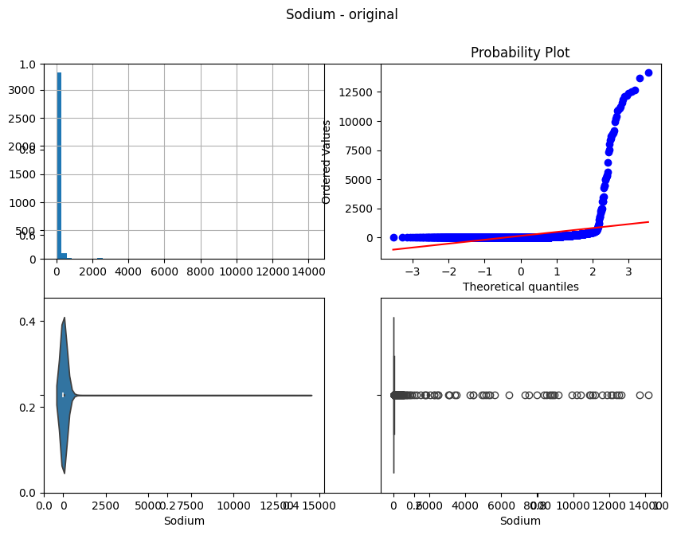

```python
diagnostic_plots(df, 'Sodium', title="Sodium - original")
```

```python
sodium = df['Sodium']

# Вычислим границы IQR
Q1 = sodium.quantile(0.25)
Q3 = sodium.quantile(0.75)
IQR = Q3 - Q1
lower_bound = Q1 - 1.5*IQR
upper_bound = Q3 + 1.5*IQR
lower_bound, upper_bound
```

```
(np.float64(-31.91625), np.float64(53.345749999999995))
```

```python
# Флаги для изменения выбросов
df['Sodium'] = np.where(sodium > upper_bound, upper_bound,
                          np.where(sodium < lower_bound, lower_bound, sodium))
title = 'Поле-{}, метод-{}'.format('Sodium', 'IRQ')
```

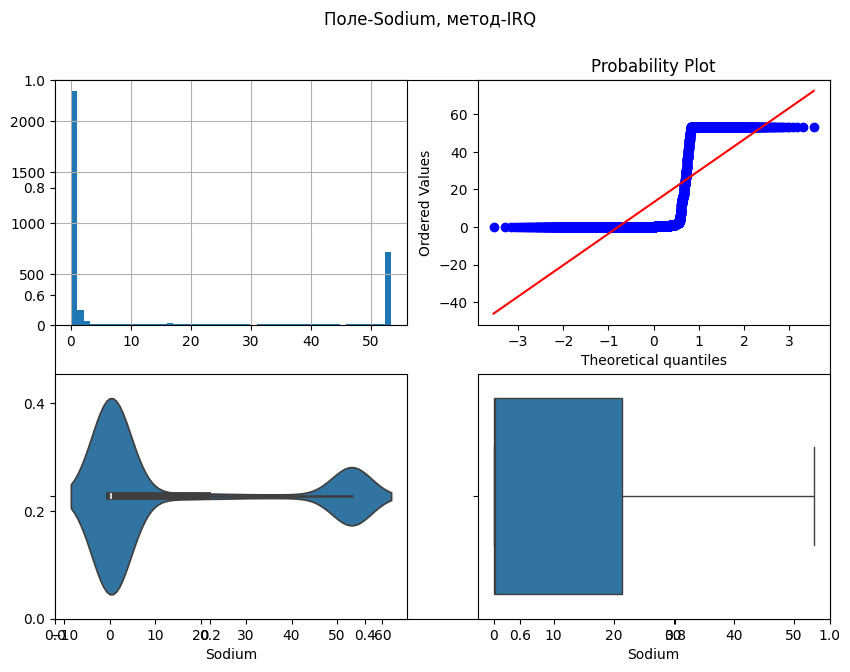

```python
diagnostic_plots(df, 'Sodium', title)
```

### **Дополнительные требования по группам:**

Для столбца 'Sodium' построим парные диаграммы с другими численными столбцами

```python
numerical_cols = [
    c for c in df.columns
    if df[c].dtype in ['float64', 'int64']
]
numerical_cols
```

```
['Vitamin C',
 'Vitamin B11',
 'Sodium',
 'Calcium',
 'Carbohydrates',
 'Iron',
 'Caloric Value',
 'Sugars',
 'Dietary Fiber',
 'Fat',
 'Protein']
```

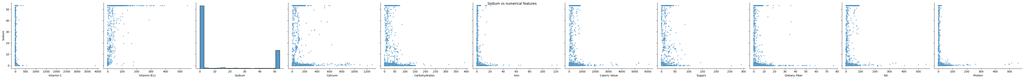

```python
sns.pairplot(
    data=df,
    x_vars=numerical_cols,
    y_vars=['Sodium'],
    plot_kws={'alpha': 0.4, 's': 20},
    height=4,
    aspect=1.2
)
plt.suptitle('Sodium vs numerical features')
plt.show()
```